# Exploratiory_Data

$$\textbf{Exploratory of the Data}$$

```python
from tabulate import tabulate
member_name = [
    ["LY Chhaythean", "Male", "I3-AMS", "e20220963"],
    ["NEANG Vanna", "Female", "I3-AMS", "e2022"],
    ["PHYRUN Pichchhorda", "Female", "I3-AMS", "e2022"],
    ["ORN Vanda", "Male", "I3-AMS", "e2022"],
    ["KUONG Sivhoung", "Female", "I3-AMS", "e2022"]
]
member_info = ["Name", "Gender", "Program", "ID"]
print("Group 5:")
print(tabulate(member_name, headers=member_info, tablefmt="fancy_grid"))
```

```
Group 5:
╒════════════════════╤══════════╤═══════════╤═══════════╕
│ Name               │ Gender   │ Program   │ ID        │
╞════════════════════╪══════════╪═══════════╪═══════════╡
│ LY Chhaythean      │ Male     │ I3-AMS    │ e20220963 │
├────────────────────┼──────────┼───────────┼───────────┤
│ NEANG Vanna        │ Female   │ I3-AMS    │ e2022     │
├────────────────────┼──────────┼───────────┼───────────┤
│ PHYRUN Pichchhorda │ Female   │ I3-AMS    │ e2022     │
├────────────────────┼──────────┼───────────┼───────────┤
│ ORN Vanda          │ Male     │ I3-AMS    │ e2022     │
├────────────────────┼──────────┼───────────┼───────────┤
│ KUONG Sivhoung     │ Female   │ I3-AMS    │ e2022     │
╘════════════════════╧══════════╧═══════════╧═══════════╛
```

$\textbf{Import the important libraries}$

```python
import pandas as pd
import numpy as np
import seaborn as sns
import matplotlib.pyplot as plt
import os
from scipy import stats
import warnings
import scipy.stats as stats
```

$\text{Load the Data}$

```python
df = pd.read_csv("D:\ITC Year 3\Semester II\Mini Project\Project\Coursera.csv")
```

```python
df.head(15)
```

|  | Course Name | University | Difficulty Level | Course Rating | Course URL | Course Description | Skills |
| --- | --- | --- | --- | --- | --- | --- | --- |
| 0 | Write A Feature Length Screenplay For Film Or ... | Michigan State University | Beginner | 4.8 | https://www.coursera.org/learn/write-a-feature... | Write a Full Length Feature Film Script In th... | Drama Comedy peering screenwriting film D... |
| 1 | Business Strategy: Business Model Canvas Analy... | Coursera Project Network | Beginner | 4.8 | https://www.coursera.org/learn/canvas-analysis... | By the end of this guided project, you will be... | Finance business plan persona (user experien... |
| 2 | Silicon Thin Film Solar Cells | �cole Polytechnique | Advanced | 4.1 | https://www.coursera.org/learn/silicon-thin-fi... | This course consists of a general presentation... | chemistry physics Solar Energy film lambda... |
| 3 | Finance for Managers | IESE Business School | Intermediate | 4.8 | https://www.coursera.org/learn/operational-fin... | When it comes to numbers, there is always more... | accounts receivable dupont analysis analysis... |
| 4 | Retrieve Data using Single-Table SQL Queries | Coursera Project Network | Beginner | 4.6 | https://www.coursera.org/learn/single-table-sq... | In this course you�ll learn how to effectively... | Data Analysis select (sql) database manageme... |
| 5 | Building Test Automation Framework using Selen... | Coursera Project Network | Beginner | 4.7 | https://www.coursera.org/learn/building-test-a... | Selenium is one of the most widely used functi... | maintenance test case test automation scree... |
| 6 | Doing Business in China Capstone | The Chinese University of Hong Kong | Advanced | 3.3 | https://www.coursera.org/learn/doing-business-... | Doing Business in China Capstone enables you t... | marketing plan Planning Marketing consumpti... |
| 7 | Programming Languages, Part A | University of Washington | Intermediate | 4.9 | https://www.coursera.org/learn/programming-lan... | This course is an introduction to the basic co... | inference ml (programming language) higher-o... |
| 8 | The Roles and Responsibilities of Nonprofit Bo... | The State University of New York | Intermediate | 4.3 | https://www.coursera.org/learn/nonprofit-gov-2 | This course provides a more in-depth look at t... | Planning Peer Review fundraising strategic ... |
| 9 | Business Russian Communication. Part 3 | Saint Petersburg State University | Intermediate | Not Calibrated | https://www.coursera.org/learn/business-russia... | Russian is considered to be one of the most di... | Russian market (economics) tax exemption co... |
| 10 | Agile Projects: Developing Tasks with Taiga | Coursera Project Network | Beginner | 4 | https://www.coursera.org/learn/developing-agil... | By the end of this guided project, you will be... | project modeling Project Management agile m... |
| 11 | Esports Management Capstone Project | University of California, Irvine | Beginner | 4.4 | https://www.coursera.org/learn/esports-managem... | We will analyze the pros and cons of creating ... | Average Planning Leadership and Management ... |
| 12 | Hacking and Patching | University of Colorado System | Advanced | 3.4 | https://www.coursera.org/learn/hacking-patching | In this MOOC, you will learn how to hack web a... | Security Design design pattern web applicati... |
| 13 | Business Statistics and Analysis Capstone | Rice University | Beginner | 4.7 | https://www.coursera.org/learn/business-statis... | The Business Statistics and Analysis Capstone ... | Statistical Analysis Microsoft Excel busines... |
| 14 | Grab Data Fast with Vertical and Horizontal LO... | Coursera Project Network | Beginner | 4.5 | https://www.coursera.org/learn/grab-data-fast-... | Data can come our way in multiple forms and fr... | evaluation software presentation lookup tab... |

```python
df["Course Rating"] = pd.to_numeric(df["Course Rating"], errors="coerce")
df.head(15)
```

|  | Course Name | University | Difficulty Level | Course Rating | Course URL | Course Description | Skills |
| --- | --- | --- | --- | --- | --- | --- | --- |
| 0 | Write A Feature Length Screenplay For Film Or ... | Michigan State University | Beginner | 4.8 | https://www.coursera.org/learn/write-a-feature... | Write a Full Length Feature Film Script In th... | Drama Comedy peering screenwriting film D... |
| 1 | Business Strategy: Business Model Canvas Analy... | Coursera Project Network | Beginner | 4.8 | https://www.coursera.org/learn/canvas-analysis... | By the end of this guided project, you will be... | Finance business plan persona (user experien... |
| 2 | Silicon Thin Film Solar Cells | �cole Polytechnique | Advanced | 4.1 | https://www.coursera.org/learn/silicon-thin-fi... | This course consists of a general presentation... | chemistry physics Solar Energy film lambda... |
| 3 | Finance for Managers | IESE Business School | Intermediate | 4.8 | https://www.coursera.org/learn/operational-fin... | When it comes to numbers, there is always more... | accounts receivable dupont analysis analysis... |
| 4 | Retrieve Data using Single-Table SQL Queries | Coursera Project Network | Beginner | 4.6 | https://www.coursera.org/learn/single-table-sq... | In this course you�ll learn how to effectively... | Data Analysis select (sql) database manageme... |
| 5 | Building Test Automation Framework using Selen... | Coursera Project Network | Beginner | 4.7 | https://www.coursera.org/learn/building-test-a... | Selenium is one of the most widely used functi... | maintenance test case test automation scree... |
| 6 | Doing Business in China Capstone | The Chinese University of Hong Kong | Advanced | 3.3 | https://www.coursera.org/learn/doing-business-... | Doing Business in China Capstone enables you t... | marketing plan Planning Marketing consumpti... |
| 7 | Programming Languages, Part A | University of Washington | Intermediate | 4.9 | https://www.coursera.org/learn/programming-lan... | This course is an introduction to the basic co... | inference ml (programming language) higher-o... |
| 8 | The Roles and Responsibilities of Nonprofit Bo... | The State University of New York | Intermediate | 4.3 | https://www.coursera.org/learn/nonprofit-gov-2 | This course provides a more in-depth look at t... | Planning Peer Review fundraising strategic ... |
| 9 | Business Russian Communication. Part 3 | Saint Petersburg State University | Intermediate | NaN | https://www.coursera.org/learn/business-russia... | Russian is considered to be one of the most di... | Russian market (economics) tax exemption co... |
| 10 | Agile Projects: Developing Tasks with Taiga | Coursera Project Network | Beginner | 4.0 | https://www.coursera.org/learn/developing-agil... | By the end of this guided project, you will be... | project modeling Project Management agile m... |
| 11 | Esports Management Capstone Project | University of California, Irvine | Beginner | 4.4 | https://www.coursera.org/learn/esports-managem... | We will analyze the pros and cons of creating ... | Average Planning Leadership and Management ... |
| 12 | Hacking and Patching | University of Colorado System | Advanced | 3.4 | https://www.coursera.org/learn/hacking-patching | In this MOOC, you will learn how to hack web a... | Security Design design pattern web applicati... |
| 13 | Business Statistics and Analysis Capstone | Rice University | Beginner | 4.7 | https://www.coursera.org/learn/business-statis... | The Business Statistics and Analysis Capstone ... | Statistical Analysis Microsoft Excel busines... |
| 14 | Grab Data Fast with Vertical and Horizontal LO... | Coursera Project Network | Beginner | 4.5 | https://www.coursera.org/learn/grab-data-fast-... | Data can come our way in multiple forms and fr... | evaluation software presentation lookup tab... |

```python
df.isnull().sum()
```

```
Course Name            0
University             0
Difficulty Level       0
Course Rating         82
Course URL             0
Course Description     0
Skills                 0
dtype: int64
```

```python
median_rating = df["Course Rating"].median()
df["Course Rating"].fillna(median_rating, inplace=True)
```

```python
df.loc[:, "Course Rating"] = df["Course Rating"].fillna(median_rating)
```

```python
df.head(20)
```

|  | Course Name | University | Difficulty Level | Course Rating | Course URL | Course Description | Skills |
| --- | --- | --- | --- | --- | --- | --- | --- |
| 0 | Write A Feature Length Screenplay For Film Or ... | Michigan State University | Beginner | 4.8 | https://www.coursera.org/learn/write-a-feature... | Write a Full Length Feature Film Script In th... | Drama Comedy peering screenwriting film D... |
| 1 | Business Strategy: Business Model Canvas Analy... | Coursera Project Network | Beginner | 4.8 | https://www.coursera.org/learn/canvas-analysis... | By the end of this guided project, you will be... | Finance business plan persona (user experien... |
| 2 | Silicon Thin Film Solar Cells | �cole Polytechnique | Advanced | 4.1 | https://www.coursera.org/learn/silicon-thin-fi... | This course consists of a general presentation... | chemistry physics Solar Energy film lambda... |
| 3 | Finance for Managers | IESE Business School | Intermediate | 4.8 | https://www.coursera.org/learn/operational-fin... | When it comes to numbers, there is always more... | accounts receivable dupont analysis analysis... |
| 4 | Retrieve Data using Single-Table SQL Queries | Coursera Project Network | Beginner | 4.6 | https://www.coursera.org/learn/single-table-sq... | In this course you�ll learn how to effectively... | Data Analysis select (sql) database manageme... |
| 5 | Building Test Automation Framework using Selen... | Coursera Project Network | Beginner | 4.7 | https://www.coursera.org/learn/building-test-a... | Selenium is one of the most widely used functi... | maintenance test case test automation scree... |
| 6 | Doing Business in China Capstone | The Chinese University of Hong Kong | Advanced | 3.3 | https://www.coursera.org/learn/doing-business-... | Doing Business in China Capstone enables you t... | marketing plan Planning Marketing consumpti... |
| 7 | Programming Languages, Part A | University of Washington | Intermediate | 4.9 | https://www.coursera.org/learn/programming-lan... | This course is an introduction to the basic co... | inference ml (programming language) higher-o... |
| 8 | The Roles and Responsibilities of Nonprofit Bo... | The State University of New York | Intermediate | 4.3 | https://www.coursera.org/learn/nonprofit-gov-2 | This course provides a more in-depth look at t... | Planning Peer Review fundraising strategic ... |
| 9 | Business Russian Communication. Part 3 | Saint Petersburg State University | Intermediate | 4.6 | https://www.coursera.org/learn/business-russia... | Russian is considered to be one of the most di... | Russian market (economics) tax exemption co... |
| 10 | Agile Projects: Developing Tasks with Taiga | Coursera Project Network | Beginner | 4.0 | https://www.coursera.org/learn/developing-agil... | By the end of this guided project, you will be... | project modeling Project Management agile m... |
| 11 | Esports Management Capstone Project | University of California, Irvine | Beginner | 4.4 | https://www.coursera.org/learn/esports-managem... | We will analyze the pros and cons of creating ... | Average Planning Leadership and Management ... |
| 12 | Hacking and Patching | University of Colorado System | Advanced | 3.4 | https://www.coursera.org/learn/hacking-patching | In this MOOC, you will learn how to hack web a... | Security Design design pattern web applicati... |
| 13 | Business Statistics and Analysis Capstone | Rice University | Beginner | 4.7 | https://www.coursera.org/learn/business-statis... | The Business Statistics and Analysis Capstone ... | Statistical Analysis Microsoft Excel busines... |
| 14 | Grab Data Fast with Vertical and Horizontal LO... | Coursera Project Network | Beginner | 4.5 | https://www.coursera.org/learn/grab-data-fast-... | Data can come our way in multiple forms and fr... | evaluation software presentation lookup tab... |
| 15 | Global Health: An Interdisciplinary Overview | University of Geneva | Beginner | 4.6 | https://www.coursera.org/learn/global-health-o... | This course proposes an overview of current gl... | sustainability research and development Comm... |
| 16 | Python Programming Essentials | Rice University | Beginner | 4.8 | https://www.coursera.org/learn/python-programming | This course will introduce you to the wonderfu... | semantics Python Programming coding conventi... |
| 17 | Creating Dashboards and Storytelling with Tableau | University of California, Davis | Advanced | 4.6 | https://www.coursera.org/learn/dataviz-dashboards | Leveraging the visualizations you created in t... | neuroscience Data Visualization Storytelling... |
| 18 | Parallel programming | �cole Polytechnique F�d�rale de Lausanne | Beginner | 4.4 | https://www.coursera.org/learn/parprog1 | With every smartphone and computer now boastin... | Data Structures parallel algorithm openfabri... |
| 19 | Recommendation Systems with TensorFlow on GCP | Google Cloud | Advanced | 4.2 | https://www.coursera.org/learn/recommendation-... | In this course, you'll apply your knowledge of... | systems architecture Cloud Computing Google ... |

```python
df.describe(include=['object']).T
```

|  | count | unique | top | freq |
| --- | --- | --- | --- | --- |
| Course Name | 3522 | 3416 | Google Cloud Platform Fundamentals: Core Infra... | 8 |
| University | 3522 | 184 | Coursera Project Network | 562 |
| Difficulty Level | 3522 | 5 | Beginner | 1444 |
| Course URL | 3522 | 3424 | https://www.coursera.org/learn/gcp-fundamentals | 8 |
| Course Description | 3522 | 3397 | This course introduces you to important concep... | 8 |
| Skills | 3522 | 3424 | Google Cloud Platform Big Data Cloud Infrast... | 8 |

$\text{Ploting the Course Rating}$

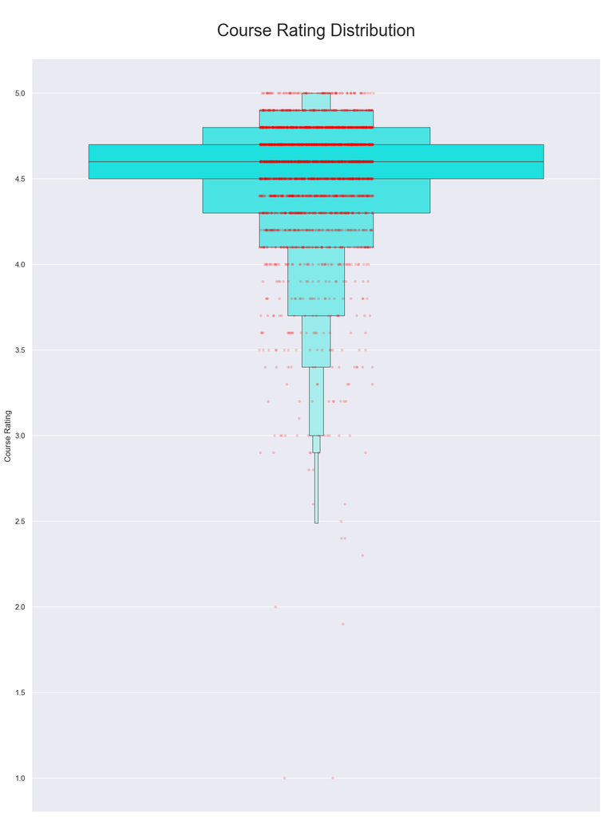

```python
sns.set(rc={'figure.figsize': (15,20)})

plt = sns.boxenplot(y="Course Rating", data=df,
                    showfliers=False,color='cyan')
plt = sns.stripplot(y="Course Rating", data = df,
                    size=4, color="red", alpha = 0.2)
plt.axes.set_title("\n Course Rating Distribution \n", fontsize = 25)
```

$\text{Ploting Course Rating to get an overview of the distribution}$

```
Shape: 150.0073, Loc: 0.0000, Scale: 0.0304
```

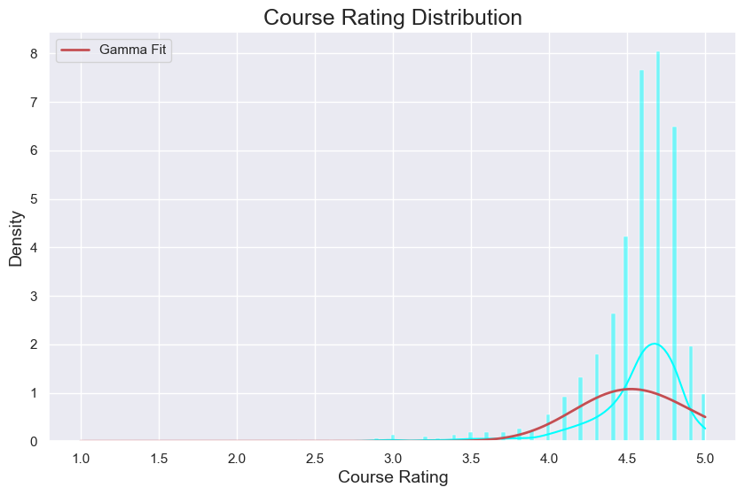

```python
import numpy as np
import pandas as pd
import scipy.stats as stats
import matplotlib.pyplot as plt
import seaborn as sns

df["Course Rating"] = pd.to_numeric(df["Course Rating"], errors='coerce')

median_rating = df["Course Rating"].median()
df["Course Rating"] = df["Course Rating"].fillna(median_rating)

ratings = df["Course Rating"]
ratings = ratings[ratings > 0]

if ratings.empty:
    raise ValueError("No valid ratings available after filtering!")

shape, loc, scale = stats.gamma.fit(ratings, floc=0)

print(f"Shape: {shape:.4f}, Loc: {loc:.4f}, Scale: {scale:.4f}")

sns.set(rc={'figure.figsize': (10, 6)})
fig, ax = plt.subplots()
sns.histplot(ratings, color='cyan', kde=True, stat="density", ax=ax)

x = np.linspace(ratings.min(), ratings.max(), 1000)
p = stats.gamma.pdf(x, shape, loc, scale)

ax.plot(x, p, 'r', label="Gamma Fit", linewidth=2)
ax.set_title("Course Rating Distribution", fontsize=18)
ax.set_xlabel("Course Rating", fontsize=14)
ax.set_ylabel("Density", fontsize=14)
ax.legend()

plt.show()
```

$$\textbf{Key Findings:}$$

$\text{Average course rating is quite higher, if we compare it to the}$

$\text{ lowest and the maximum value.}$

$\text{Then we might need to consider the Rating distribution per Course Difficulty.}$

$$\textbf{Frequency based on Difficulty}$$

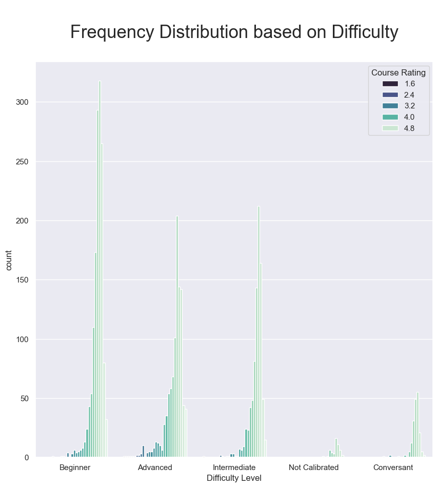

```python
sns.set(rc={'figure.figsize':(10,10)})
ax = sns.countplot(hue="Course Rating", x="Difficulty Level", data=df, palette="mako")
ax.axes.set_title("\n Frequency Distribution based on Difficulty \n", fontsize=25)
```

#### Insight:

1. Most courses fall under "Beginner," "Intermediate," and "Advanced" levels, while "Not Calibrated" and "Conversant" have significantly fewer courses.
2. Higher ratings (4.0–4.8) dominate across all difficulty levels, indicating overall positive learner satisfaction.
3. Low ratings (1.6–2.4) are rare, suggesting that most courses are well-received regardless of difficulty.
4. The rating distribution is similar across difficulty levels, meaning difficulty does not strongly impact course ratings.

$\textbf{Rating Distribution per course type:}$

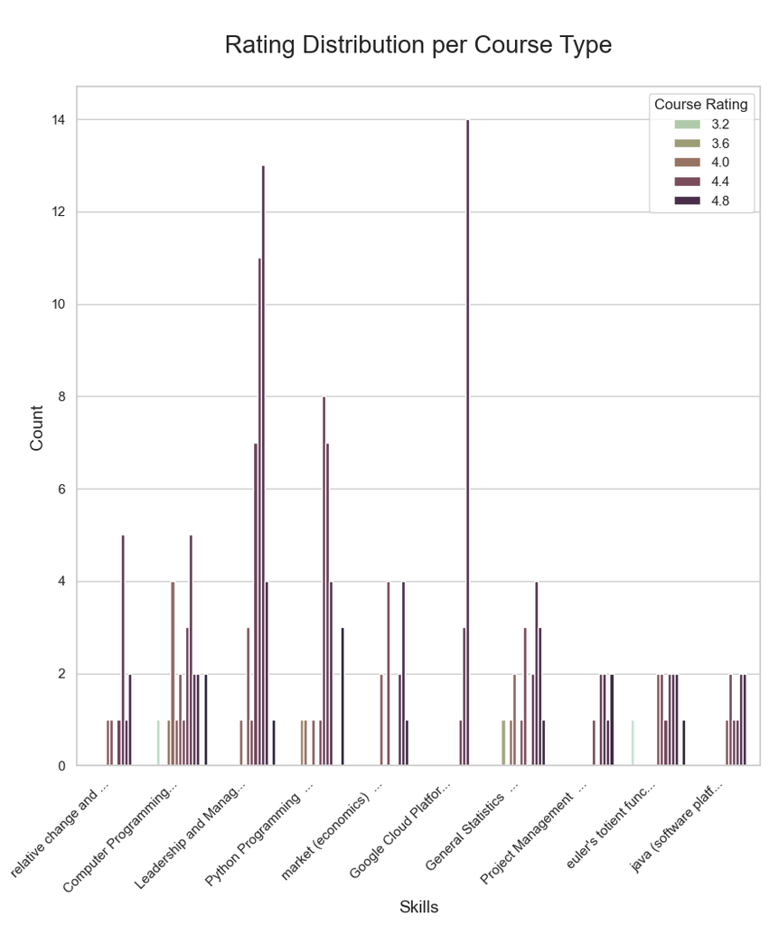

```python
df["Short Skills"] = df["Skills"].apply(lambda x: x[:20] + "..." if len(x) > 20 else x)
top_skills = df["Short Skills"].value_counts().nlargest(10).index
df_filtered = df[df["Short Skills"].isin(top_skills)]
sns.set(rc={'figure.figsize': (10, 10)})
sns.set_style("whitegrid")
ax = sns.countplot(data=df_filtered, x="Short Skills", hue="Course Rating", palette="ch:s=-.2, r=.9")
ax.set_title("\n Rating Distribution per Course Type \n", fontsize=20)
ax.set_xlabel("Skills", fontsize=14)
ax.set_ylabel("Count", fontsize=14)
ax.set_xticklabels(ax.get_xticklabels(), rotation=45, ha="right")
plt.show()
```

📊 Key Findings & Insights from the Chart

Some skills have significantly more ratings than others Python Programming, Google Cloud Platform, and Leadership & Management courses have the highest counts, meaning these topics are more popular or have more course offerings.

$\textbf{More Advanced Data Analysis}$

$\text{Advanced Cleaning}$

```python
df1 = df.copy()
```

```python
df1.head(20)
```

|  | Course Name | University | Difficulty Level | Course Rating | Course URL | Course Description | Skills | Short Skills |
| --- | --- | --- | --- | --- | --- | --- | --- | --- |
| 0 | Write A Feature Length Screenplay For Film Or ... | Michigan State University | Beginner | 4.8 | https://www.coursera.org/learn/write-a-feature... | Write a Full Length Feature Film Script In th... | Drama Comedy peering screenwriting film D... | Drama Comedy peeri... |
| 1 | Business Strategy: Business Model Canvas Analy... | Coursera Project Network | Beginner | 4.8 | https://www.coursera.org/learn/canvas-analysis... | By the end of this guided project, you will be... | Finance business plan persona (user experien... | Finance business pl... |
| 2 | Silicon Thin Film Solar Cells | �cole Polytechnique | Advanced | 4.1 | https://www.coursera.org/learn/silicon-thin-fi... | This course consists of a general presentation... | chemistry physics Solar Energy film lambda... | chemistry physics ... |
| 3 | Finance for Managers | IESE Business School | Intermediate | 4.8 | https://www.coursera.org/learn/operational-fin... | When it comes to numbers, there is always more... | accounts receivable dupont analysis analysis... | accounts receivable ... |
| 4 | Retrieve Data using Single-Table SQL Queries | Coursera Project Network | Beginner | 4.6 | https://www.coursera.org/learn/single-table-sq... | In this course you�ll learn how to effectively... | Data Analysis select (sql) database manageme... | Data Analysis selec... |
| 5 | Building Test Automation Framework using Selen... | Coursera Project Network | Beginner | 4.7 | https://www.coursera.org/learn/building-test-a... | Selenium is one of the most widely used functi... | maintenance test case test automation scree... | maintenance test ca... |
| 6 | Doing Business in China Capstone | The Chinese University of Hong Kong | Advanced | 3.3 | https://www.coursera.org/learn/doing-business-... | Doing Business in China Capstone enables you t... | marketing plan Planning Marketing consumpti... | marketing plan Plan... |
| 7 | Programming Languages, Part A | University of Washington | Intermediate | 4.9 | https://www.coursera.org/learn/programming-lan... | This course is an introduction to the basic co... | inference ml (programming language) higher-o... | inference ml (progr... |
| 8 | The Roles and Responsibilities of Nonprofit Bo... | The State University of New York | Intermediate | 4.3 | https://www.coursera.org/learn/nonprofit-gov-2 | This course provides a more in-depth look at t... | Planning Peer Review fundraising strategic ... | Planning Peer Revie... |
| 9 | Business Russian Communication. Part 3 | Saint Petersburg State University | Intermediate | 4.6 | https://www.coursera.org/learn/business-russia... | Russian is considered to be one of the most di... | Russian market (economics) tax exemption co... | Russian market (eco... |
| 10 | Agile Projects: Developing Tasks with Taiga | Coursera Project Network | Beginner | 4.0 | https://www.coursera.org/learn/developing-agil... | By the end of this guided project, you will be... | project modeling Project Management agile m... | project modeling P... |
| 11 | Esports Management Capstone Project | University of California, Irvine | Beginner | 4.4 | https://www.coursera.org/learn/esports-managem... | We will analyze the pros and cons of creating ... | Average Planning Leadership and Management ... | Average Planning L... |
| 12 | Hacking and Patching | University of Colorado System | Advanced | 3.4 | https://www.coursera.org/learn/hacking-patching | In this MOOC, you will learn how to hack web a... | Security Design design pattern web applicati... | Security Design des... |
| 13 | Business Statistics and Analysis Capstone | Rice University | Beginner | 4.7 | https://www.coursera.org/learn/business-statis... | The Business Statistics and Analysis Capstone ... | Statistical Analysis Microsoft Excel busines... | Statistical Analysis... |
| 14 | Grab Data Fast with Vertical and Horizontal LO... | Coursera Project Network | Beginner | 4.5 | https://www.coursera.org/learn/grab-data-fast-... | Data can come our way in multiple forms and fr... | evaluation software presentation lookup tab... | evaluation software... |
| 15 | Global Health: An Interdisciplinary Overview | University of Geneva | Beginner | 4.6 | https://www.coursera.org/learn/global-health-o... | This course proposes an overview of current gl... | sustainability research and development Comm... | sustainability rese... |
| 16 | Python Programming Essentials | Rice University | Beginner | 4.8 | https://www.coursera.org/learn/python-programming | This course will introduce you to the wonderfu... | semantics Python Programming coding conventi... | semantics Python Pr... |
| 17 | Creating Dashboards and Storytelling with Tableau | University of California, Davis | Advanced | 4.6 | https://www.coursera.org/learn/dataviz-dashboards | Leveraging the visualizations you created in t... | neuroscience Data Visualization Storytelling... | neuroscience Data V... |
| 18 | Parallel programming | �cole Polytechnique F�d�rale de Lausanne | Beginner | 4.4 | https://www.coursera.org/learn/parprog1 | With every smartphone and computer now boastin... | Data Structures parallel algorithm openfabri... | Data Structures par... |
| 19 | Recommendation Systems with TensorFlow on GCP | Google Cloud | Advanced | 4.2 | https://www.coursera.org/learn/recommendation-... | In this course, you'll apply your knowledge of... | systems architecture Cloud Computing Google ... | systems architecture... |

$\text{Modifying Difficulty Level column to numerical to further analysis}$

```python
def modify(x):
    if x == "Beginner":
        return "0"
    elif x == "Intermediate":
        return "1"
    elif x == "Conversant":
        return "0.5"
    elif x == "Advanced":
        return "2"
    else:
        return "0"
```

```python
df1['Difficulty Level Modified'] = df1['Difficulty Level'].apply(modify)
df1['Difficulty Level Modified'] = df1['Difficulty Level Modified'].apply(pd.to_numeric)
df_1 = df1.drop(['Difficulty Level'],axis=1)
df_1
```

|  | Course Name | University | Course Rating | Course URL | Course Description | Skills | Short Skills | Difficulty Level Modified |
| --- | --- | --- | --- | --- | --- | --- | --- | --- |
| 0 | Write A Feature Length Screenplay For Film Or ... | Michigan State University | 4.8 | https://www.coursera.org/learn/write-a-feature... | Write a Full Length Feature Film Script In th... | Drama Comedy peering screenwriting film D... | Drama Comedy peeri... | 0.0 |
| 1 | Business Strategy: Business Model Canvas Analy... | Coursera Project Network | 4.8 | https://www.coursera.org/learn/canvas-analysis... | By the end of this guided project, you will be... | Finance business plan persona (user experien... | Finance business pl... | 0.0 |
| 2 | Silicon Thin Film Solar Cells | �cole Polytechnique | 4.1 | https://www.coursera.org/learn/silicon-thin-fi... | This course consists of a general presentation... | chemistry physics Solar Energy film lambda... | chemistry physics ... | 2.0 |
| 3 | Finance for Managers | IESE Business School | 4.8 | https://www.coursera.org/learn/operational-fin... | When it comes to numbers, there is always more... | accounts receivable dupont analysis analysis... | accounts receivable ... | 1.0 |
| 4 | Retrieve Data using Single-Table SQL Queries | Coursera Project Network | 4.6 | https://www.coursera.org/learn/single-table-sq... | In this course you�ll learn how to effectively... | Data Analysis select (sql) database manageme... | Data Analysis selec... | 0.0 |
| ... | ... | ... | ... | ... | ... | ... | ... | ... |
| 3517 | Capstone: Retrieving, Processing, and Visualiz... | University of Michigan | 4.6 | https://www.coursera.org/learn/python-data-vis... | In the capstone, students will build a series ... | Databases syntax analysis web Data Visuali... | Databases syntax a... | 0.0 |
| 3518 | Patrick Henry: Forgotten Founder | University of Virginia | 4.9 | https://www.coursera.org/learn/henry | �Give me liberty, or give me death:� Rememberi... | retirement Causality career history of the ... | retirement Causalit... | 1.0 |
| 3519 | Business intelligence and data analytics: Gene... | Macquarie University | 4.6 | https://www.coursera.org/learn/business-intell... | �Megatrends� heavily influence today�s organis... | analytics tableau software Business Intellig... | analytics tableau s... | 2.0 |
| 3520 | Rigid Body Dynamics | Korea Advanced Institute of Science and Techno... | 4.6 | https://www.coursera.org/learn/rigid-body-dyna... | This course teaches dynamics, one of the basic... | Angular Mechanical Design fluid mechanics F... | Angular Mechanical ... | 0.0 |
| 3521 | Architecting with Google Kubernetes Engine: Pr... | Google Cloud | 4.7 | https://www.coursera.org/learn/deploying-secur... | In this course, "Architecting with Google Kube... | bigtable bigquery SQL Google Cloud Platform... | bigtable bigquery ... | 1.0 |

3522 rows × 8 columns

$\textbf{Let's see some pairplot}$

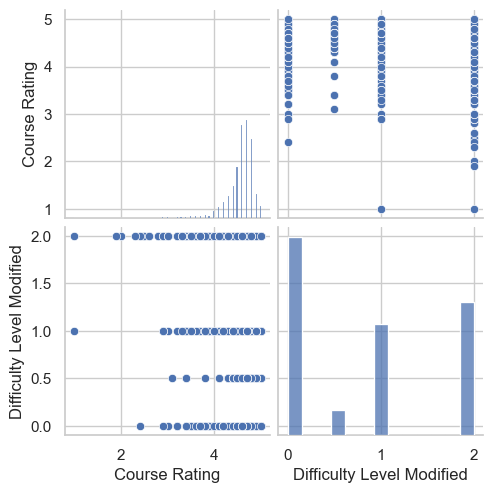

```python
plt.figure(figsize=(15,15))
sns.pairplot(df1, vars=['Course Rating', 'Difficulty Level Modified'])
```

```python
df_1[['Difficulty Level Modified', 'Course Rating']].describe()
```

|  | Difficulty Level Modified | Course Rating |
| --- | --- | --- |
| count | 3522.000000 | 3522.000000 |
| mean | 0.834753 | 4.555537 |
| std | 0.834047 | 0.333365 |
| min | 0.000000 | 1.000000 |
| 25% | 0.000000 | 4.500000 |
| 50% | 1.000000 | 4.600000 |
| 75% | 2.000000 | 4.700000 |
| max | 2.000000 | 5.000000 |

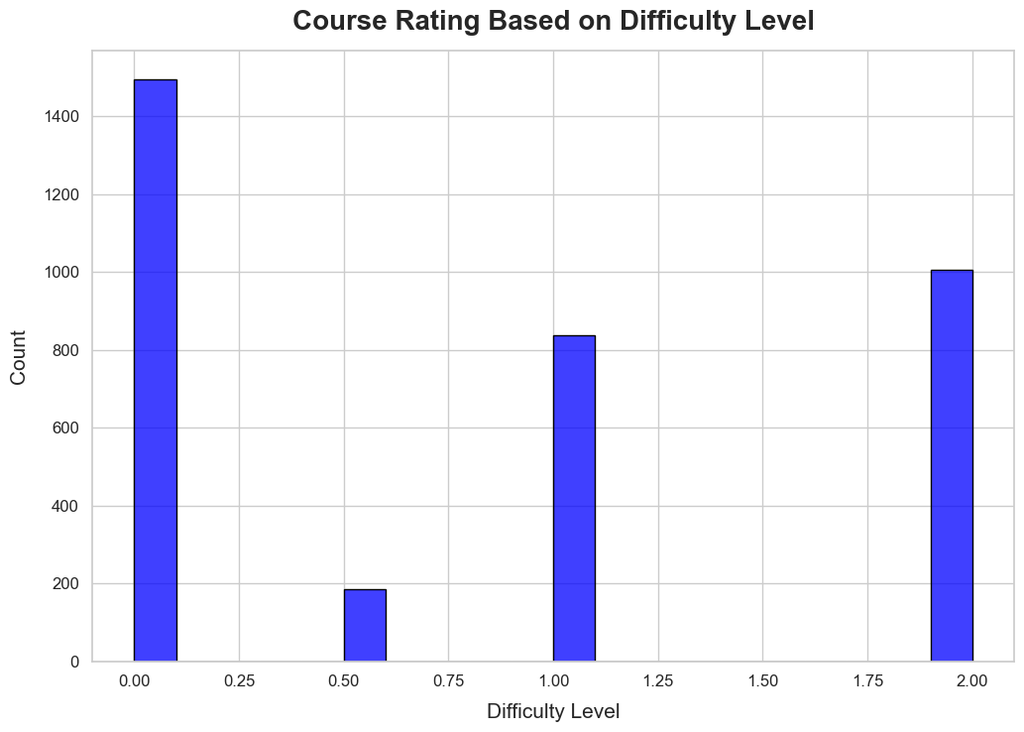

```python
plt.figure(figsize=(12, 8))

p = sns.histplot(df_1['Difficulty Level Modified'], color='blue', edgecolor='black', bins=20)
p.set_title("Course Rating Based on Difficulty Level", fontsize=20, fontweight='bold', pad=15)
p.set_xlabel("Difficulty Level", fontsize=15, labelpad=10)
p.set_ylabel("Count", fontsize=15, labelpad=10)
p.tick_params(axis='both', which='major', labelsize=12)
plt.show()
```

$\textbf{In order to consider the Model that we will going to use we are going to}$

1. Calculate the sum, mean, median, min and max of the Course Rating Column

```python
rating_sum = df_1['Course Rating'].sum()
rating_mean = df_1['Course Rating'].mean()
rating_median = df_1['Course Rating'].median()
rating_max = df_1['Course Rating'].max()
rating_min = df_1['Course Rating'].min()
```

```python
print(f'Sum: {rating_sum}, Mean: {rating_mean}, Median: {rating_median}, Min: {rating_min}, Max: {rating_max}')
```

```
Sum: 16044.599999999999, Mean: 4.555536626916524, Median: 4.6, Min: 1.0, Max: 5.0
```

2. Check Correlation Annalysis

```python
df_numeric = df_1.select_dtypes(include=np.number)
```

```python
Corr = df_numeric.corr()
Corr
```

|  | Course Rating | Difficulty Level Modified |
| --- | --- | --- |
| Course Rating | 1.000000 | -0.148243 |
| Difficulty Level Modified | -0.148243 | 1.000000 |

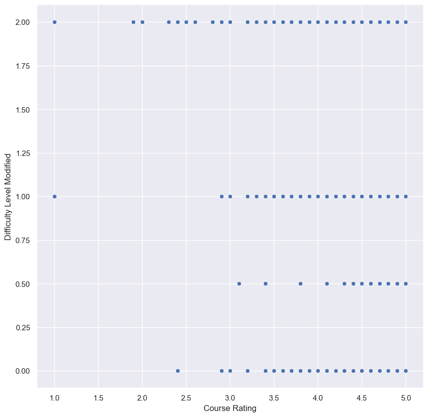

```python
sns.set(rc={'figure.figsize': (10,10)})
ax = sns.scatterplot(x='Course Rating', y='Difficulty Level Modified', data=df_numeric, palette='crest')
```

$\text{Yooohooooooooooooooooo, No effective Coorelation}$

$\textbf{Review Sentiment Analysis}$

```python
data1 = pd.read_csv("D:\ITC Year 3\Semester II\Mini Project\Project\Coursera_reviews.csv")
```

```python
data1.head(5)
```

|  | reviews | reviewers | date_reviews | rating | course_id |
| --- | --- | --- | --- | --- | --- |
| 0 | Pretty dry, but I was able to pass with just t... | By Robert S | Feb 12, 2020 | 4 | google-cbrs-cpi-training |
| 1 | would be a better experience if the video and ... | By Gabriel E R | Sep 28, 2020 | 4 | google-cbrs-cpi-training |
| 2 | Information was perfect! The program itself wa... | By Jacob D | Apr 08, 2020 | 4 | google-cbrs-cpi-training |
| 3 | A few grammatical mistakes on test made me do ... | By Dale B | Feb 24, 2020 | 4 | google-cbrs-cpi-training |
| 4 | Excellent course and the training provided was... | By Sean G | Jun 18, 2020 | 4 | google-cbrs-cpi-training |

```python
# Install required libraries (if not already installed)
try:
    import nltk
    import wordcloud
    import pillow
    import cufflinks as cf
    import vaderSentiment
except ImportError:
    import sys
    !{sys.executable} -m pip install wordcloud pillow nltk cufflinks vaderSentiment

# Import necessary modules
from wordcloud import WordCloud, STOPWORDS, ImageColorGenerator
from PIL import Image
import nltk
import numpy as np  # Needed for image processing
import matplotlib.pyplot as plt
from nltk.corpus import stopwords
from nltk.stem.porter import PorterStemmer
from collections import Counter
import cufflinks as cf
from nltk.sentiment import SentimentIntensityAnalyzer

# Download required NLTK resources
nltk.download('stopwords')
nltk.download('vader_lexicon')

# Initialize sentiment analyzer
analyser = SentimentIntensityAnalyzer()

# Enable offline mode for cufflinks
cf.go_offline()
```

[output not shown]

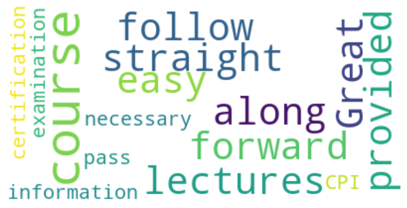

```python
wordcloud = WordCloud(max_font_size=50, max_words=100, background_color="white").generate(data1.reviews[10])
plt.imshow(wordcloud, interpolation='bilinear')
plt.axis("off")
plt.show()
```

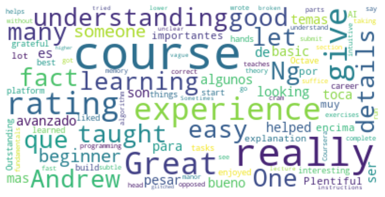

```python
wordcloud = WordCloud(max_font_size=50, max_words=100, background_color="white").generate(' '.join(data1.sample(10).reviews))
plt.imshow(wordcloud, interpolation='bilinear')
plt.axis("off")
plt.show()
```

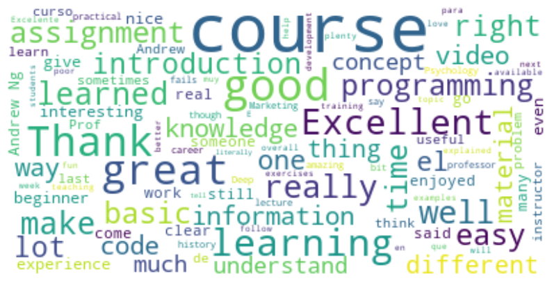

```python
wordcloud = WordCloud(max_font_size=50, max_words=100, background_color="white").generate(' '.join(data1.sample(100).reviews))
plt.imshow(wordcloud, interpolation='bilinear')
plt.axis("off")
plt.show()
```

$\textbf{Generating Review Sentiments using Vader Sentiment}$

```python
def sentiment_analyzer(sentence):
    score = analyser.polarity_scores(sentence)
    return score
```

```python
neg=[]
neu=[]
pos=[]
comp=[]
for review in data1.reviews:
    scores = sentiment_analyzer(str(review))
    neg.append(scores['neg'])
    pos.append(scores['pos'])
    neu.append(scores['neu'])
    comp.append(scores['compound'])
```

$$\textbf{Review Analysis}$$

```python
data1['s_pos'] = pos
data1['s_neu'] = neu
data1['s_neg'] = neg
data1['s_comp'] = comp
```

```python
data1.head()
```

|  | reviews | reviewers | date_reviews | rating | course_id | s_pos | s_neu | s_neg | s_comp |
| --- | --- | --- | --- | --- | --- | --- | --- | --- | --- |
| 0 | Pretty dry, but I was able to pass with just t... | By Robert S | Feb 12, 2020 | 4 | google-cbrs-cpi-training | 0.160 | 0.738 | 0.102 | 0.6440 |
| 1 | would be a better experience if the video and ... | By Gabriel E R | Sep 28, 2020 | 4 | google-cbrs-cpi-training | 0.057 | 0.943 | 0.000 | 0.4404 |
| 2 | Information was perfect! The program itself wa... | By Jacob D | Apr 08, 2020 | 4 | google-cbrs-cpi-training | 0.168 | 0.735 | 0.097 | 0.6572 |
| 3 | A few grammatical mistakes on test made me do ... | By Dale B | Feb 24, 2020 | 4 | google-cbrs-cpi-training | 0.193 | 0.717 | 0.090 | 0.4633 |
| 4 | Excellent course and the training provided was... | By Sean G | Jun 18, 2020 | 4 | google-cbrs-cpi-training | 0.384 | 0.616 | 0.000 | 0.7823 |

```python
for i in range(6,11):
    print ("----------------------------------------")
    print("Review : ",data1['reviews'][i])
    print("Positivity:",data1['s_pos'][i])
    print("Negativity:",data1['s_neg'][i])
    print ("----------------------------------------")
```

```
----------------------------------------
Review :  Solid presentation all the way through. I really appreciated the intermittent questions that popped up to check on learning as well the regular (but not needless) quizzing. There was visuals such as charts / .ppt for those of us more visually inclined as well as a transcript below the vide…
Positivity: 0.165
Negativity: 0.0
----------------------------------------
----------------------------------------
Review :  Probably the best certification course I've taken in this respect. The course is planned out carefully, and I believe gave me everything I needed to ace my exam the first time around. The trainer for the majority of the course was awesome. She delivered the material in a great, professiona…
Positivity: 0.222
Negativity: 0.0
----------------------------------------
----------------------------------------
Review :  The ProctorU.com system took 2 times the amount of time spent on this course over 3 days to complete.  It is the worse production user system I have used in 20+ years of my IT career.    You should switch to another vendor.
Positivity: 0.0
Negativity: 0.075
----------------------------------------
----------------------------------------
Review :  Covered all of the required information in an easy to understand way and WITH VIDEO! Great, easy way to learn. The exam process was a bit drawn out and more extensive then it needed to be, but over all a great experience
Positivity: 0.256
Negativity: 0.0
----------------------------------------
----------------------------------------
Review :  Great course, lectures were straight forward and easy to follow along.  The course provided all the information necessary to pass the CPI examination for certification.
Positivity: 0.288
Negativity: 0.0
----------------------------------------
```

$\textbf{Sentiment Distribution}$

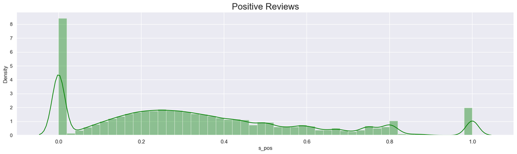

```python
sns.set(rc={'figure.figsize':(20,5)})
plt.xticks(fontsize=12)
p=sns.distplot(data1['s_pos'],color='green')
p.axes.set_title("Positive Reviews",fontsize=20)
```

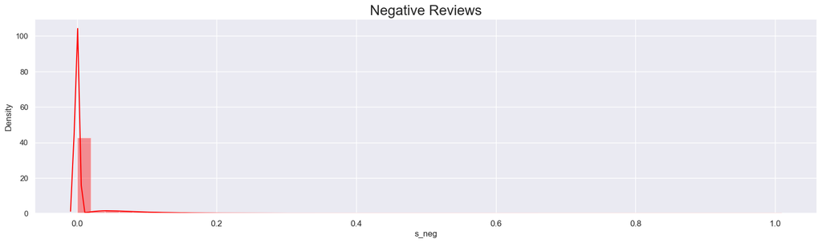

```python
sns.set(rc={'figure.figsize':(20,5)})
plt.xticks(fontsize=12)
p=sns.distplot(data1['s_neg'],color='red')
p.axes.set_title("Negative Reviews",fontsize=20)
```

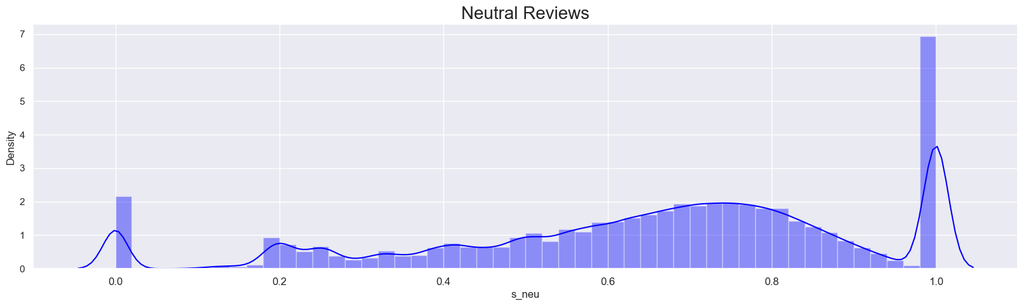

```python
sns.set(rc={'figure.figsize':(20,5)})
plt.xticks(fontsize=12)
p=sns.distplot(data1['s_neu'],color='blue')
p.axes.set_title("Neutral Reviews",fontsize=20)
```

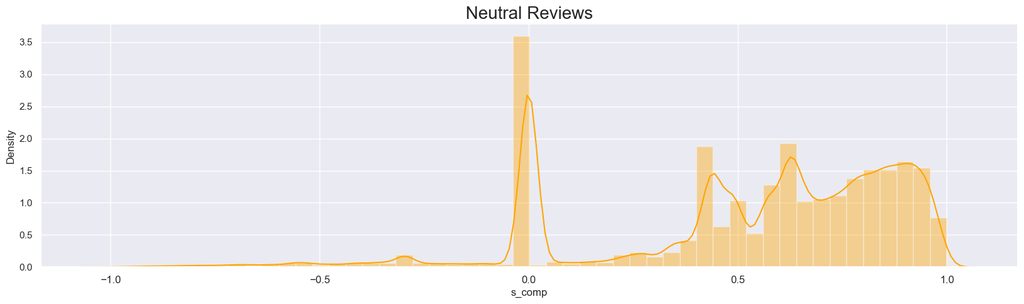

```python
sns.set(rc={'figure.figsize':(20,5)})
plt.xticks(fontsize=12)
p=sns.distplot(data1['s_comp'],color='orange')
p.axes.set_title("Neutral Reviews",fontsize=20)
```

```python
course_wise = data1.groupby('course_id')[['s_comp', 'rating']].mean()
```

```python
course_wise['s_comp']=((course_wise['s_comp']*10)+10)/4
course_wise
```

| course_id | s_comp | rating |
| --- | --- | --- |
| aboriginal-education | 4.140701 | 4.604061 |
| access-control-sscp | 3.568584 | 4.572519 |
| accounting-analytics | 3.792649 | 4.426991 |
| accounting-data-analytics-python | 3.752063 | 3.500000 |
| actualizacion-manejo-diabetes-tipo-2 | 2.417052 | 4.867052 |
| ... | ... | ... |
| womens-health-human-rights | 4.127003 | 4.894231 |
| write-a-feature-length-screenplay-for-film-or-television | 3.993567 | 4.666667 |
| write-your-first-novel | 3.718207 | 3.942308 |
| writing-editing-words | 4.005276 | 4.776699 |
| writing-for-business | 3.988497 | 4.811780 |

604 rows × 2 columns

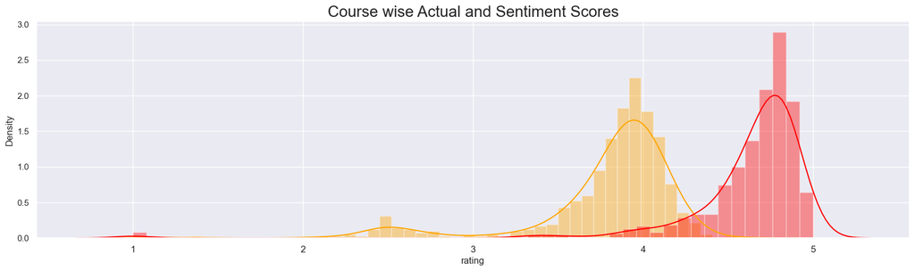

```python
sns.set(rc={'figure.figsize':(20,5)})
plt.xticks(fontsize=12)
p=sns.distplot(course_wise['s_comp'],color='orange')
p=sns.distplot(course_wise['rating'],color='red')
p.axes.set_title("Course wise Actual and Sentiment Scores",fontsize=20)
```

$\textbf{Key Observation}$

$\text{- Overall given rating is higher than sentiment scores.}$

$\textbf{Co-Relation}$

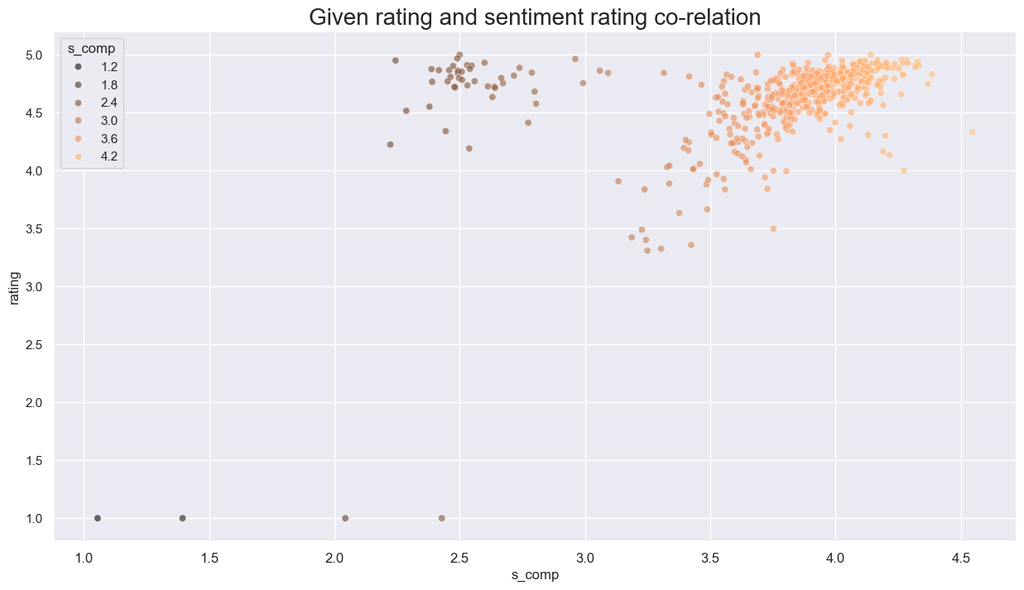

```python
sns.set(rc={'figure.figsize':(15,8)})
plt.xticks(fontsize=12)
p=sns.scatterplot(data=course_wise,x='s_comp',y='rating',palette='copper',hue='s_comp',alpha=0.6)
p.axes.set_title("Given rating and sentiment rating co-relation",fontsize=20)
```